# 3144419 _CSCU9M3_Aut2023

## Part 1:Dataset Selection and Justificat

I chose a dataset of bad_password. Passowrds are important for securing important stuff wether it on phone or on web we use passowrds in our daily life bad passwords can result in the can provide helpful knowledge into user behaviour and potential security holes. **columns**: 1)password: in our dataset we are using passwords as string as interger 2)offline_crack_sec:the time taken in seconds to crack passwords **justification**: 1)awareness:Testing the bad passwords can help us raise awareness about the about the security of the user or the company.seeing a common pattern in our weak passwords it can help both the user and orgranization as well for better password procedures. 2)vulnerablity:discovering the dataset might undercover flaws and patters which are used by the hackers. The data is useful because it can help in imporving security. 3)user_behavior:revewing at bad_passwords tell us information of the user behavior when it comes to the password creation. The user should create strong and unique password. https://www.kaggle.com/datasets/sujaykapadnis/bad-passwords-never-use-them

## Part 2: Data Cleaning and Transformation

```python
import pandas as pd
import numpy as np
import seaborn as sns
df=pd.read_csv("bad_passwords.csv")
print(df.head())
```

```
   rank  password             category  value time_unit  offline_crack_sec  \
0     1  password     password-related   6.91     years       2.170000e+00
1     2    123456  simple-alphanumeric  18.52   minutes       1.110000e-05
2     3  12345678  simple-alphanumeric   1.29      days       1.110000e-03
3     4      1234  simple-alphanumeric  11.11   seconds       1.110000e-07
4     5    qwerty  simple-alphanumeric   3.72      days       3.210000e-03

   rank_alt  strength  font_size
0         1         8         11
1         2         4          8
2         3         4          8
3         4         4          8
4         5         8         11
```

```python
#part1
print(df.info())
```

[output not shown]

```python
#part2
df["offline_crack_sec"] = pd.to_numeric(df["offline_crack_sec"])
df
```

|  | rank | password | category | value | time_unit | offline_crack_sec | rank_alt | strength | font_size |
| --- | --- | --- | --- | --- | --- | --- | --- | --- | --- |
| 0 | 1 | password | password-related | 6.91 | years | 2.170000e+00 | 1 | 8 | 11 |
| 1 | 2 | 123456 | simple-alphanumeric | 18.52 | minutes | 1.110000e-05 | 2 | 4 | 8 |
| 2 | 3 | 12345678 | simple-alphanumeric | 1.29 | days | 1.110000e-03 | 3 | 4 | 8 |
| 3 | 4 | 1234 | simple-alphanumeric | 11.11 | seconds | 1.110000e-07 | 4 | 4 | 8 |
| 4 | 5 | qwerty | simple-alphanumeric | 3.72 | days | 3.210000e-03 | 5 | 8 | 11 |
| ... | ... | ... | ... | ... | ... | ... | ... | ... | ... |
| 495 | 496 | reddog | cool-macho | 3.72 | days | 3.210000e-03 | 498 | 6 | 10 |
| 496 | 497 | alexande | name | 6.91 | years | 2.170000e+00 | 499 | 9 | 12 |
| 497 | 498 | college | nerdy-pop | 3.19 | months | 8.350000e-02 | 500 | 7 | 11 |
| 498 | 499 | jester | name | 3.72 | days | 3.210000e-03 | 501 | 7 | 11 |
| 499 | 500 | passw0rd | password-related | 92.27 | years | 2.902000e+01 | 502 | 28 | 21 |

500 rows × 9 columns

```python
#part3
df["length"] = df["password"].apply(len)
df
```

[output not shown]

```python
#part4
df["font_size_norm"] = df["font_size"] / df["font_size"].max()
df
```

|  | rank | password | category | value | time_unit | offline_crack_sec | rank_alt | strength | font_size | length | font_size_norm |
| --- | --- | --- | --- | --- | --- | --- | --- | --- | --- | --- | --- |
| 0 | 1 | password | password-related | 6.91 | years | 2.170000e+00 | 1 | 8 | 11 | 8 | 0.392857 |
| 1 | 2 | 123456 | simple-alphanumeric | 18.52 | minutes | 1.110000e-05 | 2 | 4 | 8 | 6 | 0.285714 |
| 2 | 3 | 12345678 | simple-alphanumeric | 1.29 | days | 1.110000e-03 | 3 | 4 | 8 | 8 | 0.285714 |
| 3 | 4 | 1234 | simple-alphanumeric | 11.11 | seconds | 1.110000e-07 | 4 | 4 | 8 | 4 | 0.285714 |
| 4 | 5 | qwerty | simple-alphanumeric | 3.72 | days | 3.210000e-03 | 5 | 8 | 11 | 6 | 0.392857 |
| ... | ... | ... | ... | ... | ... | ... | ... | ... | ... | ... | ... |
| 495 | 496 | reddog | cool-macho | 3.72 | days | 3.210000e-03 | 498 | 6 | 10 | 6 | 0.357143 |
| 496 | 497 | alexande | name | 6.91 | years | 2.170000e+00 | 499 | 9 | 12 | 8 | 0.428571 |
| 497 | 498 | college | nerdy-pop | 3.19 | months | 8.350000e-02 | 500 | 7 | 11 | 7 | 0.392857 |
| 498 | 499 | jester | name | 3.72 | days | 3.210000e-03 | 501 | 7 | 11 | 6 | 0.392857 |
| 499 | 500 | passw0rd | password-related | 92.27 | years | 2.902000e+01 | 502 | 28 | 21 | 8 | 0.750000 |

500 rows × 11 columns

```python
print(df.isnull().sum())
```

[output not shown]

## Part 3: Exploratory Data Analysis (EDA)

```python
import pandas as pd
import numpy as np
import matplotlib.pylab as plt
import seaborn as sns
plt.style.use('ggplot')
pd.set_option('display.max_columns', 100)
```

```python
df=pd.read_csv("bad_passwords.csv")
df
```

|  | rank | password | category | value | time_unit | offline_crack_sec | rank_alt | strength | font_size |
| --- | --- | --- | --- | --- | --- | --- | --- | --- | --- |
| 0 | 1 | password | password-related | 6.91 | years | 2.170000e+00 | 1 | 8 | 11 |
| 1 | 2 | 123456 | simple-alphanumeric | 18.52 | minutes | 1.110000e-05 | 2 | 4 | 8 |
| 2 | 3 | 12345678 | simple-alphanumeric | 1.29 | days | 1.110000e-03 | 3 | 4 | 8 |
| 3 | 4 | 1234 | simple-alphanumeric | 11.11 | seconds | 1.110000e-07 | 4 | 4 | 8 |
| 4 | 5 | qwerty | simple-alphanumeric | 3.72 | days | 3.210000e-03 | 5 | 8 | 11 |
| ... | ... | ... | ... | ... | ... | ... | ... | ... | ... |
| 495 | 496 | reddog | cool-macho | 3.72 | days | 3.210000e-03 | 498 | 6 | 10 |
| 496 | 497 | alexande | name | 6.91 | years | 2.170000e+00 | 499 | 9 | 12 |
| 497 | 498 | college | nerdy-pop | 3.19 | months | 8.350000e-02 | 500 | 7 | 11 |
| 498 | 499 | jester | name | 3.72 | days | 3.210000e-03 | 501 | 7 | 11 |
| 499 | 500 | passw0rd | password-related | 92.27 | years | 2.902000e+01 | 502 | 28 | 21 |

500 rows × 9 columns

```python
#dtypes
df.dtypes
```

[output not shown]

```python
#part2
df.head()
```

|  | rank | password | category | value | time_unit | offline_crack_sec | rank_alt | strength | font_size |
| --- | --- | --- | --- | --- | --- | --- | --- | --- | --- |
| 0 | 1 | password | password-related | 6.91 | years | 2.170000e+00 | 1 | 8 | 11 |
| 1 | 2 | 123456 | simple-alphanumeric | 18.52 | minutes | 1.110000e-05 | 2 | 4 | 8 |
| 2 | 3 | 12345678 | simple-alphanumeric | 1.29 | days | 1.110000e-03 | 3 | 4 | 8 |
| 3 | 4 | 1234 | simple-alphanumeric | 11.11 | seconds | 1.110000e-07 | 4 | 4 | 8 |
| 4 | 5 | qwerty | simple-alphanumeric | 3.72 | days | 3.210000e-03 | 5 | 8 | 11 |

```python
#part 3
df.groupby('category')['strength'].describe()
```

| category | count | mean | std | min | 25% | 50% | 75% | max |
| --- | --- | --- | --- | --- | --- | --- | --- | --- |
| animal | 29.0 | 7.551724 | 1.088453 | 6.0 | 7.0 | 7.0 | 8.0 | 10.0 |
| cool-macho | 79.0 | 7.215190 | 1.737010 | 0.0 | 6.0 | 8.0 | 8.0 | 10.0 |
| fluffy | 44.0 | 6.772727 | 1.776640 | 0.0 | 6.0 | 7.0 | 8.0 | 9.0 |
| food | 11.0 | 4.363636 | 2.419617 | 0.0 | 3.5 | 5.0 | 6.0 | 7.0 |
| name | 183.0 | 7.191257 | 1.456901 | 0.0 | 6.0 | 8.0 | 8.0 | 10.0 |
| nerdy-pop | 30.0 | 14.000000 | 13.431820 | 6.0 | 8.0 | 8.0 | 9.0 | 48.0 |
| password-related | 15.0 | 7.866667 | 5.853774 | 3.0 | 6.0 | 7.0 | 8.0 | 28.0 |
| rebellious-rude | 11.0 | 6.727273 | 1.902152 | 2.0 | 6.5 | 7.0 | 8.0 | 9.0 |
| simple-alphanumeric | 61.0 | 5.852459 | 9.731112 | 0.0 | 0.0 | 4.0 | 6.0 | 36.0 |
| sport | 37.0 | 8.000000 | 4.570436 | 4.0 | 7.0 | 8.0 | 8.0 | 34.0 |

```python
#part4
df.shape
```

```
(500, 9)
```

```python
#part5
df.columns
```

```
Index(['rank', 'password', 'category', 'value', 'time_unit',
       'offline_crack_sec', 'rank_alt', 'strength', 'font_size'],
      dtype='object')
```

```python
#renaming the columns
df = df.rename(columns={
    'rank': 'Rank',
    'password': 'Password',
    'category': 'Category',
    'value': 'Value',
    'time_unit': 'Time_Unit',
    'offline_crack_sec': 'Offline_Crack_Sec',
    'rant_alt': 'Rant_Alt',
    'strength': 'Strength',
    'font_size': 'Font_Size'
})
```

```python
#part6
df.describe()
```

|  | Rank | Value | Offline_Crack_Sec | rank_alt |
| --- | --- | --- | --- | --- |
| count | 500.000000 | 500.000000 | 5.000000e+02 | 500.000000 |
| mean | 250.500000 | 5.602660 | 5.000096e-01 | 251.224000 |
| std | 144.481833 | 8.436005 | 2.658132e+00 | 145.052163 |
| min | 1.000000 | 1.290000 | 1.110000e-07 | 1.000000 |
| 25% | 125.750000 | 3.430000 | 3.210000e-03 | 125.750000 |
| 50% | 250.500000 | 3.720000 | 3.210000e-03 | 251.500000 |
| 75% | 375.250000 | 3.720000 | 8.350000e-02 | 376.250000 |
| max | 500.000000 | 92.270000 | 2.927000e+01 | 502.000000 |

```python
#info
df.info()
```

```
<class 'pandas.core.frame.DataFrame'>
RangeIndex: 500 entries, 0 to 499
Data columns (total 7 columns):
 #   Column             Non-Null Count  Dtype
---  ------             --------------  -----
 0   Rank               500 non-null    int64
 1   Password           500 non-null    object
 2   Category           500 non-null    object
 3   Value              500 non-null    float64
 4   Time_Unit          500 non-null    object
 5   Offline_Crack_Sec  500 non-null    float64
 6   rank_alt           500 non-null    int64
dtypes: float64(2), int64(2), object(3)
memory usage: 27.5+ KB
```

```python
#summry statics
print("\n summary statisitic")
print(df.describe())
```

```
 summary statisitic
             Rank       Value  Offline_Crack_Sec    rank_alt
count  500.000000  500.000000       5.000000e+02  500.000000
mean   250.500000    5.602660       5.000096e-01  251.224000
std    144.481833    8.436005       2.658132e+00  145.052163
min      1.000000    1.290000       1.110000e-07    1.000000
25%    125.750000    3.430000       3.210000e-03  125.750000
50%    250.500000    3.720000       3.210000e-03  251.500000
75%    375.250000    3.720000       8.350000e-02  376.250000
max    500.000000   92.270000       2.927000e+01  502.000000
```

```python
# part9 duplication
df.loc[df.duplicated()]
```

|  | Rank | Password | Category | Value | Time_Unit | Offline_Crack_Sec | rank_alt |
| --- | --- | --- | --- | --- | --- | --- | --- |

```python
# part 10 missing values
df.isna().sum
```

```
<bound method NDFrame._add_numeric_operations.<locals>.sum of       Rank  Password  Category  Value  Time_Unit  Offline_Crack_Sec  rank_alt
0    False     False     False  False      False              False     False
1    False     False     False  False      False              False     False
2    False     False     False  False      False              False     False
3    False     False     False  False      False              False     False
4    False     False     False  False      False              False     False
..     ...       ...       ...    ...        ...                ...       ...
495  False     False     False  False      False              False     False
496  False     False     False  False      False              False     False
497  False     False     False  False      False              False     False
498  False     False     False  False      False              False     False
499  False     False     False  False      False              False     False

[500 rows x 7 columns]>
```

```python
print(df.columns)
df['password'].value_counts()
```

```
Index(['rank', 'password', 'category', 'value', 'time_unit',
       'offline_crack_sec', 'rank_alt', 'strength', 'font_size'],
      dtype='object')
```

```
password
password    1
tester      1
scott       1
sydney      1
skippy      1
           ..
miller      1
lakers      1
spider      1
monster     1
passw0rd    1
Name: count, Length: 500, dtype: int64
```

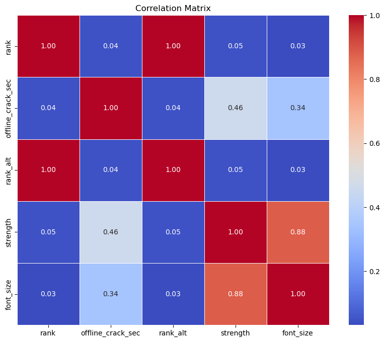

```python
#corrolation
import seaborn as sns
import matplotlib.pyplot as plt

# Calculate correlation matrix
correlation_matrix = df[['rank', 'offline_crack_sec', 'rank_alt', 'strength', 'font_size']].corr()

# Plot the correlation matrix
plt.figure(figsize=(10, 8))
sns.heatmap(correlation_matrix, annot=True, cmap='coolwarm', fmt='.2f', linewidths=.5)
plt.title('Correlation Matrix')
plt.show()
```

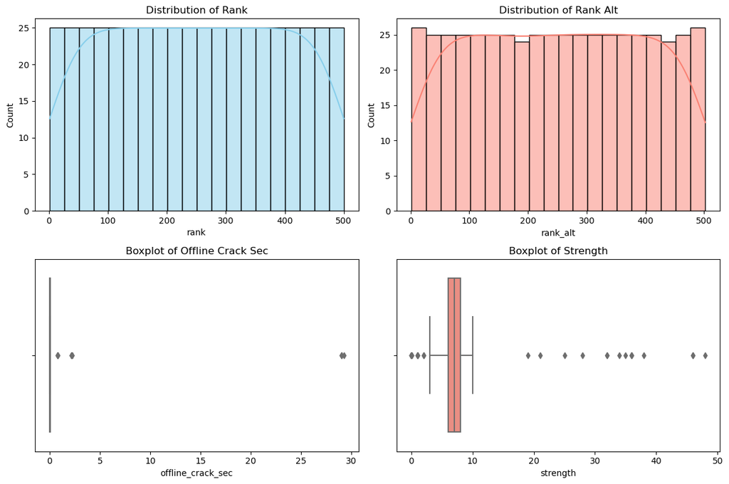

```python
# Visualize the distribution of numerical columns
plt.figure(figsize=(12, 8))

# Example histograms for rank and rank_alt
plt.subplot(2, 2, 1)
sns.histplot(df['rank'], bins=20, kde=True, color='skyblue')
plt.title('Distribution of Rank')

plt.subplot(2, 2, 2)
sns.histplot(df['rank_alt'], bins=20, kde=True, color='salmon')
plt.title('Distribution of Rank Alt')

# Example boxplots for offline_crack_sec and strength
plt.subplot(2, 2, 3)
sns.boxplot(x=df['offline_crack_sec'], color='skyblue')
plt.title('Boxplot of Offline Crack Sec')

plt.subplot(2, 2, 4)
sns.boxplot(x=df['strength'], color='salmon')
plt.title('Boxplot of Strength')

plt.tight_layout()
plt.show()
```

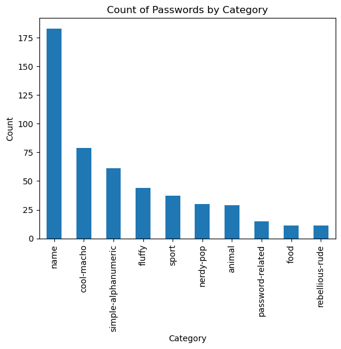

```python
#barchat
import pandas as pd
import matplotlib.pyplot as plt
df = pd.read_csv('bad_passwords.csv')
df['category'].value_counts().plot(kind='bar')
plt.title('Count of Passwords by Category')
plt.xlabel('Category')
plt.ylabel('Count')
plt.savefig('password_cat_bar.png')
```

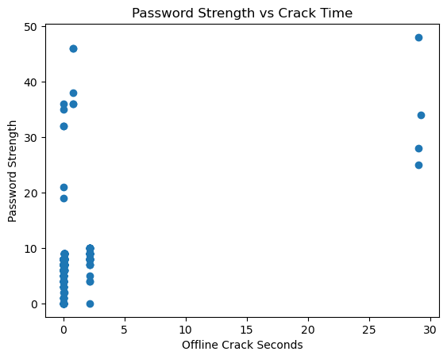

```python
#scatter plot
import pandas as pd
import matplotlib.pyplot as plt

df = pd.read_csv('bad_passwords.csv')
plt.scatter(df['offline_crack_sec'], df['strength'])
plt.title('Password Strength vs Crack Time')
plt.xlabel('Offline Crack Seconds')
plt.ylabel('Password Strength')
plt.savefig('password_scatter.png')
```

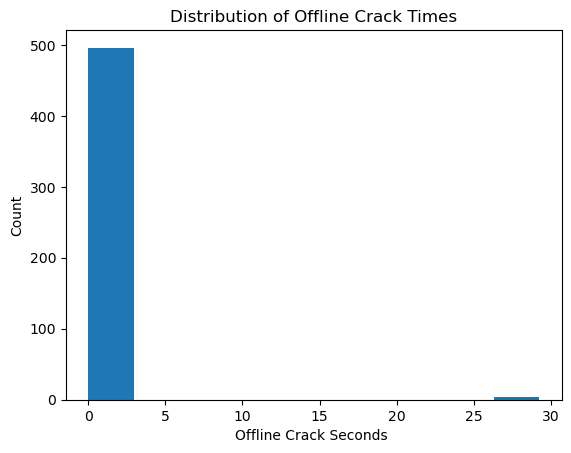

```python
#histogram
import pandas as pd
import matplotlib.pyplot as plt

# Read in the CSV
df = pd.read_csv('bad_passwords.csv')
plt.hist(df['offline_crack_sec'])
plt.title('Distribution of Offline Crack Times')
plt.xlabel('Offline Crack Seconds ')
plt.ylabel('Count')
plt.savefig('password_hist.png')
```

```python
import pandas as pd

df = pd.read_csv('bad_passwords.csv')

# Replace non-numeric values with NaN
df['offline_crack_sec'] = pd.to_numeric(df['offline_crack_sec'], errors='coerce')

# Filter dataframe to only rows with valid numbers
numeric_df = df[df['offline_crack_sec'].notnull()]

# Select only the numeric columns
numeric_cols = ['value', 'offline_crack_sec', 'rank_alt', 'strength', 'font_size']
corr_matrix = numeric_df[numeric_cols].corr()

print(corr_matrix)
```

```
                      value  offline_crack_sec  rank_alt  strength  font_size
value              1.000000           0.912406  0.038882  0.326875   0.148389
offline_crack_sec  0.912406           1.000000  0.044481  0.459596   0.344939
rank_alt           0.038882           0.044481  1.000000  0.046636   0.032290
strength           0.326875           0.459596  0.046636  1.000000   0.884827
font_size          0.148389           0.344939  0.032290  0.884827   1.000000
```

**df.dtypes**:it is use tell us about the type of the variable datatype. **df.shape** it tell us about the rows and columns of dataset **df.groupby**('category')['strength'].describe() it is use to perform orperations on dataframe. **df.columns** we will use df because it is our dataframe we are using coloumns as attributes because it contain stuff like password, category , rank , values **df = df.rename(columns={ 'rank': 'Rank', 'password': 'Password', 'category': 'Category', 'value': 'Value', 'time_unit': 'Time_Unit', 'offline_crack_sec': 'Offline_Crack_Sec', 'rant_alt': 'Rant_Alt', 'strength': 'Strength', 'font_size': 'Font_Size' })**In this code here we are using rename methord which is use allow us to change the attributes name like at data it said password in small letter but using this code i change it to capital letters. **df.describe()**The dataframe is for descriptive statics which are generated when we use the describe function in dataframe it is use to provide a summary of statictic of each dataframe. **barchar** **df = pd.read_csv('bad_passwords.csv') df['category'].value_counts().plot(kind='bar') plt.title('Count of Passwords by Category') plt.xlabel('Category') plt.ylabel('Count') plt.savefig('password_cat_bar.png')** pd.read_csv('bad_passwords.csv') it is use to read the cvs file df['category'].value_counts()it is use to count each unique value in category column category_counts.plot(kind='bar') it is use to cretate bar plot plt.title('Count of Passwords by Category') we use this to set the title name of the plot plt.xlabel('Category') and plt.ylabel('Count') it use to set Category as x axis and Count on y axis

**scatter plot** **df = pd.read_csv('bad_passwords.csv')** it is use to read our cvs files from pandas dataframe **plt.scatter(df['offline_crack_sec'], df['strength'])** it is use to create the scatter plot by using offline_crack_sec as x axis and strength as y axis **plt.title('Password Strength vs Crack Time')** we are using this as title of our plot **plt.xlabel('Offline Crack Seconds')**we are using offline_crack_sec as x axis **plt.ylabel('Password Strength')** we are using strength as y axis **plt.savefig('password_scatter.png')**it is use to save the plot as a picture

**histogram**

**plt.hist(df['offline_crack_sec'])**It is use to create histogram for offline_crack_sec and for count. **plt.title('Distribution of Offline Crack Times')**it is use to set the title of the plot **plt.xlabel('Offline Crack Seconds ')** we will use Offline_Crack_sec as x axis **plt.ylabel('Count')** we will use count as y axis **plt.savefig('password_hist.png')**it is use to save the plot as image.

**corrolation**

**correlation_matrix = df[['rank', 'offline_crack_sec', 'rank_alt', 'strength', 'font_size']].corr()** this line contains the subset of columns which contains (rank , offline_crack_sec , rank_alt , strength, font_size

**plt.figure(figsize=(10, 8))** The line contain the size of the figure such as width is 10 and height is 8

**sns.heatmap(correlation_matrix, annot=True, cmap='coolwarm', fmt='.2f', linewidths=.5)** By using this line in which the seaborn is use to create the heatmap function

**plt.title('Correlation Matrix')** We will use corrolation matrix as our title name **plt.show()** This line of code will excute and show us the output

**Visualize the distribution of numerical columns**

**plt.figure(figsize=(12, 8))** This line will create a figure of width 12 and height as 8

**plt.subplot(2, 2, 1)** we have a (2x2) grid formaton in which it would generate the subplot. **sns.histplot(df['rank'], bins=20, kde=True, color='skyblue')** This line of code will generate the histogram for the rank column and we will use colour as skyblue.

**plt.title('Distribution of Rank')** we are using this as an title for our diagram

**sns.histplot(df['rank_alt'], bins=20, kde=True, color='salmon')** this line of code will generate us the histogram for our(rank_alt) we will use salmon as a colour.

**plt.title('Distribution of Rank Alt')** we will use this as the title of our output.

**plt.subplot(2, 2, 3)** we have a (2x2) grid formaton in which it would generate the subplot.

**sns.boxplot(x=df['offline_crack_sec'], color='skyblue')** we will create a boxplot for the offline_crack_sec and we will use sky blue as our colour

**plt.title('Boxplot of Offline Crack Sec')** we will use this as our title

**plt.subplot(2, 2, 4)** we have a (2x2) grid formaton in which it would generate the subplot.

**sns.boxplot(x=df['strength'], color='salmon')** we will create a boxplot for the strength and we will use salmon as our colour

**plt.title('Boxplot of Strength')** we will use this as title.

**plt.tight_layout() plt.show()** it will show the end result

## Part 4: Data Visualisation

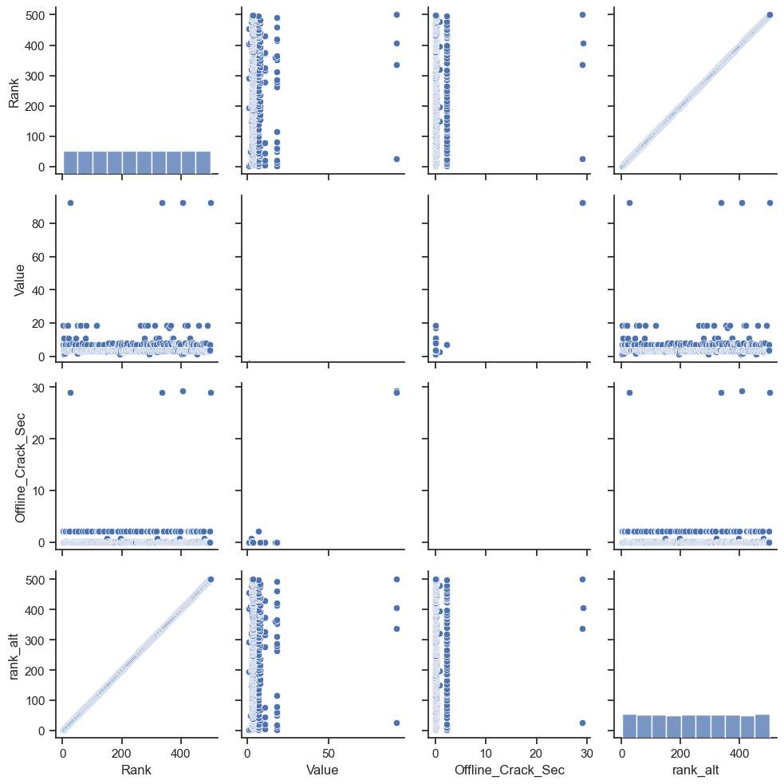

```python
#1
import seaborn as sns
import matplotlib.pyplot as plt

sns.set(style="ticks")
sns.pairplot(df)

plt.tight_layout()

plt.show()
```

[figure not shown]

```python
#2
import matplotlib.pyplot as plt
import seaborn as sns


sns.set(style="whitegrid")


fig, ax = plt.subplots(figsize=(14, 8))


sns.barplot(x='strength', y='category', data=df, ax=ax, palette='viridis')

ax.set_xlabel('Strength', fontsize=10)
ax.set_ylabel('Category', fontsize=10)
ax.set_title('Strength of Passwords and  Category', fontsize=12)

ax.tick_params(axis='x', labelrotation=40, labelsize=13)

ax.tick_params(axis='y', labelsize=10)


plt.show()
```

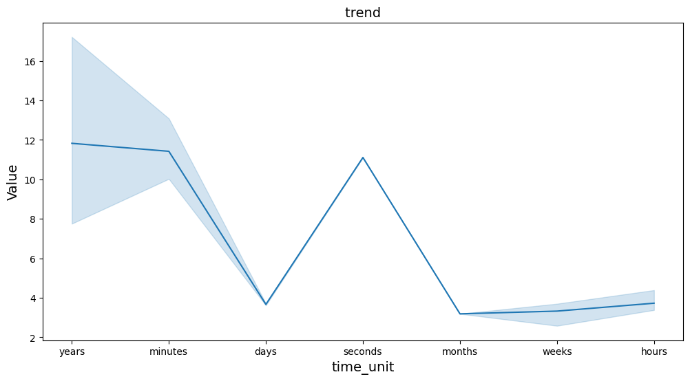

```python
#3
#lineplot
import matplotlib.pyplot as plt
import seaborn as sns

#  'df' is our  DataFrame
plt.figure(figsize=(12, 6))
sns.lineplot(x='time_unit', y='value', data=df)

# Add labels and title such as time_unit  value  and value trend
plt.xlabel('time_unit', fontsize=14)
plt.ylabel('Value', fontsize=14)
plt.title(' trend ', fontsize=14)

# Show the plot
plt.show()
```

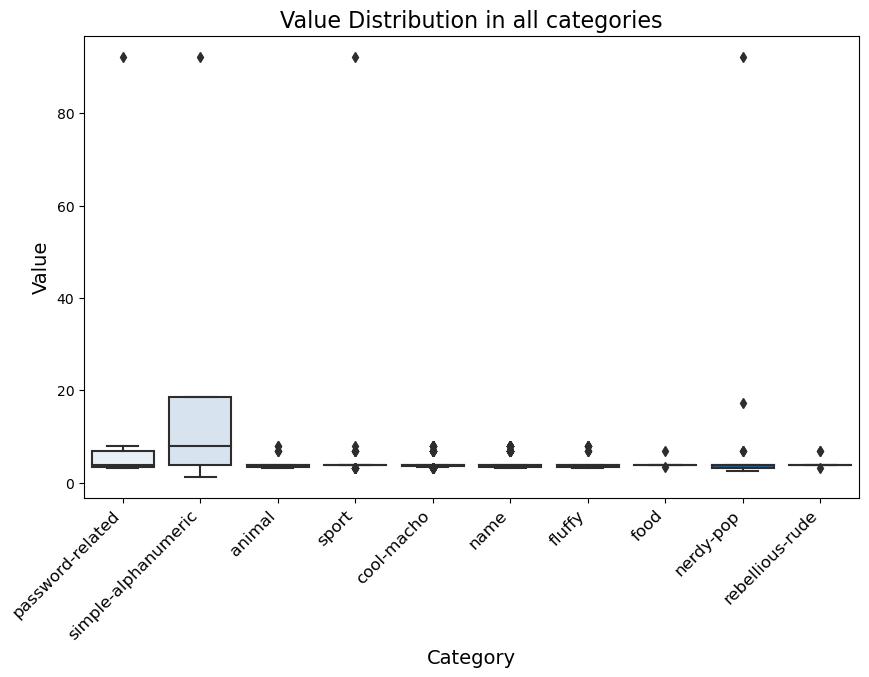

```python
#4
#box plot
plt.figure(figsize=(10, 6))
sns.boxplot(x='category', y='value', data=df, palette='Blues')

plt.xlabel('Category', fontsize=14)
plt.ylabel('Value', fontsize=14)
plt.title('Value Distribution in all categories', fontsize=16)


plt.xticks(rotation=45, ha='right', fontsize=12)


plt.show()
```

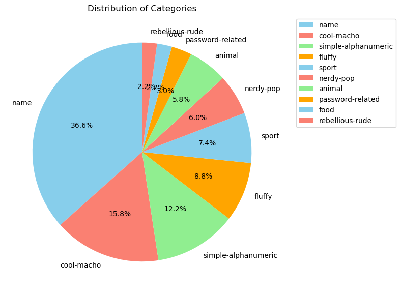

```python
#5piechart
import pandas as pd
import matplotlib.pyplot as plt

# Assuming you have a DataFrame named df with a 'category' column
df = pd.read_csv("bad_passwords.csv")

category_counts = df['category'].value_counts()

# Create a pie chart
plt.figure(figsize=(8, 8))
plt.pie(category_counts, labels=category_counts.index, autopct='%1.1f%%', startangle=90, colors=['skyblue', 'salmon', 'lightgreen', 'orange'])

# Move the legend outside the pie chart
plt.legend(bbox_to_anchor=(1.05, 1), loc='upper left')

plt.title('Distribution of Categories')

# Adjust layout for better readability
plt.tight_layout()

plt.show()
```

**explaination** 1)**import seaborn as sns** **import matplotlib.pyplot as plt** **sns.set(style="ticks")** This line of code will show us the design of seaborn as we are using ticks **sns.pairplot(df)** We will use seaborn pairplot functon which will generate a scatter plot for us in each columns in dataframe and we will compare it to each columns **plt.tight_layout()** This line of code is use to modify the plot so it can prevent it frokm overlapping **plt.show()** this line of code will excute the code and show us the output

2)import matplotlib.pyplot as plt import seaborn as sns **sns.set(style="whitegrid")** we will use the seaborn style which we using is white for our background **fig, ax = plt.subplots(figsize=(14, 8))** It is use to create a figure of the given axis.

**sns.barplot(x='strength', y='category', data=df, ax=ax, palette='viridis')**we will create the barplot by using x axis as strength , and on y axis is category.

**ax.set_xlabel('Strength', fontsize=10)** we will use the fontsize of 10 for the x axis **ax.set_ylabel('Category', fontsize=10)** we will use this fontsize of 10 for y axis **ax.set_title('Strength of Passwords and Category', fontsize=12)** we will use this as our title **ax.tick_params(axis='x', labelrotation=40, labelsize=13)** we will adjust and rotate our x axis for better reading purpose **ax.tick_params(axis='y', labelsize=10)** we will adjust and rotate our y axis for better reading purpose **plt.show()** this line of code will use to print our output

3)import matplotlib.pyplot as plt import seaborn as sns **plt.figure(figsize=(12, 6))** we will set the size for our plot such as width of 12 and height of 6 **sns.lineplot(x='time_unit', y='value', data=df)** we will create the line plot in which x axis would time_unit y axis would be 'value'.

**plt.xlabel('time_unit', fontsize=14)** On the x axis we will use time_unit and font size of 14 **plt.ylabel('Value', fontsize=14)** on y axis we will use Value and font size of 14 **plt.title('trend ', fontsize=14)** we will use trend as our title

**plt.show()** it will show us the output

4) **plt.figure(figsize=(10, 6))** we will set the size of our plot with the width of 10 , height of 6. **sns.boxplot(x='category', y='value', data=df, palette='Blues')** we will use the seaborn in order to create boxplot x as category and y as value .

**plt.xlabel('Category', fontsize=14)** we will label our x axis as Category and it font size would be 14 **plt.ylabel('Value', fontsize=14)** we will label our y axis as Value and it font size would be 14 **plt.title('Value Distribution in all categories', fontsize=16)** we will use this as our title

**plt.xticks(rotation=45, ha='right', fontsize=12)** in this line of code we are use to rotate x axis lable so we can easily read the Ha.

**plt.show()** it is use to excute the code

5)**import pandas as pd** **import matplotlib.pyplot as plt** **df = pd.read_csv("bad_passwords.csv")**

**category_counts = df['category'].value_counts()** we will use this line of to because it is use to generate the class in our dataframe in our dataset we are using category column.

**plt.figure(figsize=(8, 8))** we will use the width as 8 and height as 8 as well **plt.pie(category_counts, labels=category_counts.index, autopct='%1.1f%%', startangle=90, colors=['skyblue', 'salmon', 'lightgreen', 'orange'])** we will use pie chart data which i use to represent number of items in each category , category_count. index is use to generate lable for each part in pie chart , autopct is use to involbe certain amount of labels and using decimals for each part of pie chart **plt.title('Distribution of Categories')** we will use this our title **plt.show()** it will print out the result.

## Part 5: Data Storytelling*

## Password Secrets Revealed

## Introduction

Passwords are the most important thing which is use to keep us safe password are barrier which keep us save in our online lives. In the dataset it will show trends about the password security we have attributes such as rank, password, category, value, time_unit, offline_crack_sec, rank_alt, strength, and font_size.

## STRENGTH OF THE PASSWORDS

we will start our research we will look at the strength of passwords we will compare them to different category by using bar plot . The strength between the links shows fascinating details into strenght of the username and password through out each group.

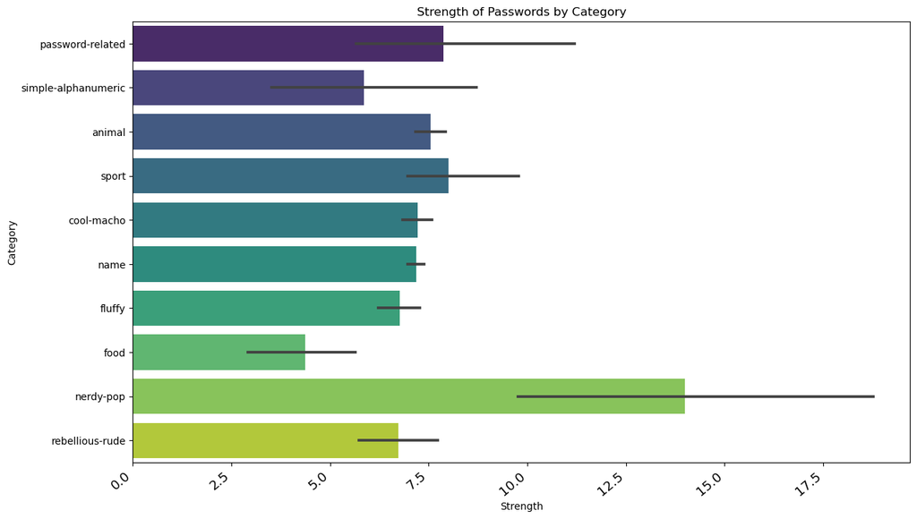

```python
import matplotlib.pyplot as plt
import seaborn as sns

plt.figure(figsize=(14, 8))

sns.barplot(x='strength', y='category', data=df, palette='viridis')
#use x as strength
plt.xlabel('Strength', fontsize=10)

plt.ylabel('Category', fontsize=10)

plt.title('Strength of Passwords by Category', fontsize=12)

plt.xticks(rotation=40, ha='right', fontsize=13)


plt.show()
```

## Investigating Time-associated Trends

we will use the lineplot for our dataset to study for time dimension we will see certan variables grow over time by displaying values towards time_unt the study shows trends how it could effect the password security.The line plot is use to identify patterns in our dataset through out the time.

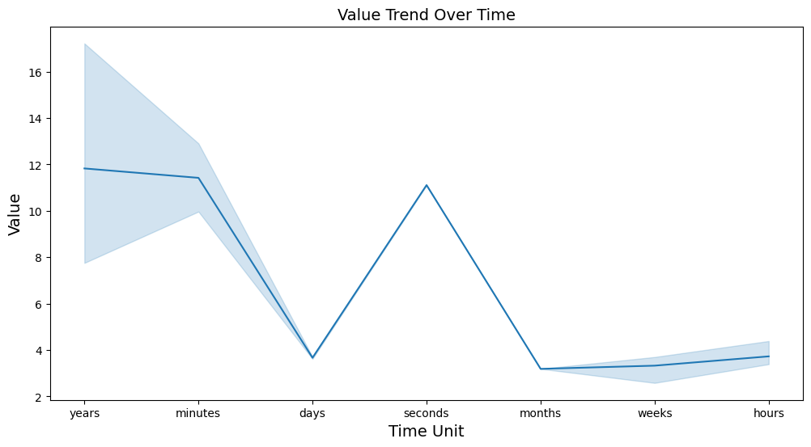

```python
plt.figure(figsize=(12, 6))
sns.lineplot(x='time_unit', y='value', data=df)
plt.xlabel('Time Unit', fontsize=14)
plt.ylabel('Value', fontsize=14)
plt.title('Value Trend Over Time', fontsize=14)
plt.show()
```

## **Category Value Distribution**

To get a better knowledge about the values about the attributes which were split through out different categories we will use the boxplot to identify trends through practising the main trends and distribution of values within categories

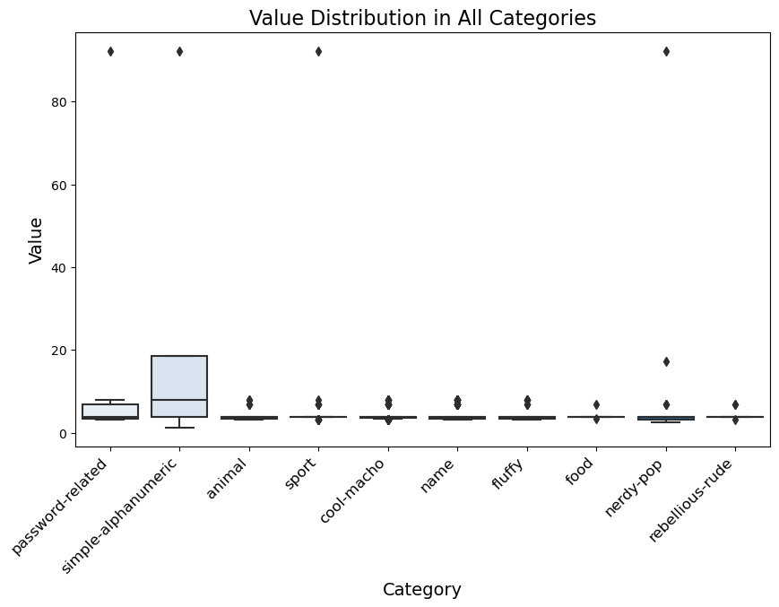

```python
plt.figure(figsize=(10, 6))
sns.boxplot(x='category', y='value', data=df, palette='Blues')
plt.xlabel('Category', fontsize=14)
plt.ylabel('Value', fontsize=14)
plt.title('Value Distribution in All Categories', fontsize=16)
plt.xticks(rotation=45, ha='right', fontsize=12)
plt.show()
```

## **A pie chart reveals category composition**

To wrap our study we used the pie chart to figure out breakdown of categories the chart will show graphical representation of our dataset all category. we will use the The pie chart was an exciting finale, gathering the main points of the dataset

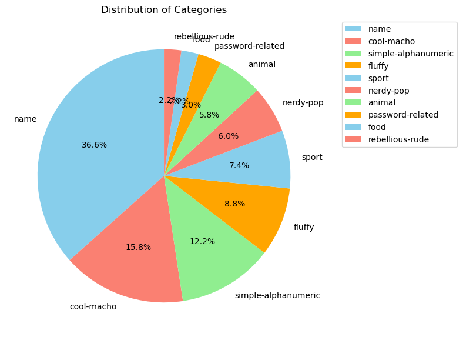

```python
import pandas as pd
import matplotlib.pyplot as plt

# Assuming you have a DataFrame named df with a 'category' column
df = pd.read_csv("bad_passwords.csv")

category_counts = df['category'].value_counts()

# Create a pie chart
plt.figure(figsize=(8, 8))
plt.pie(category_counts, labels=category_counts.index, autopct='%1.1f%%', startangle=90, colors=['skyblue', 'salmon', 'lightgreen', 'orange'])

# Move the legend outside the pie chart
plt.legend(bbox_to_anchor=(1.05, 1), loc='upper left')

plt.title('Distribution of Categories')

# Adjust layout for better readability
plt.tight_layout()

plt.show()
```

## conclusion

The study of the dataset revealed a multifaceted story of password security, including strength spread, time frame trends, category-specific insights, and overall category composition. We have simplified the confusing world of passwords by combining data analysis with requiring visualisations, providing helpful information for cybersecurity practitioners and enthusiasts alike. The journey of passwords takes place as we get around a complex network of digits and characters, urging us to consider the fragile balance between security and usability in the digital era .

## Part 6: Challenges and Reflection

1)

## Cleaning and Exploration of Data:

Working with missing or incorrect information can be difficult. Knowing the distribution of data and deciding how to handle outliers required careful thought. 2)In order to make decisons about the data cleaning and eda we used the methords which involved such as visualization and having the knowledge of field

## Visualisation Difficulties:

1) by selecting the data for visualization the analysis proved to be difficult and by selecting the certain colours and plots which can be a main factor because readbility is the important thing.

## data seclection

The dataset are rarely perfect it requries finding the data , cleaning, and visualisation of data is the methord which is use for finding trends and gaining ideas

## The Value of Visualisation:

Visualisations plays important role expressing the ideas it doesnt help with break down of data but it act as important tool for communication .

## storyTelling with data

we will create the data story which conatins results and is converted into a single story . The story telling of thw data improves the communication and helps understand of complex test.